```python
import pandas as pd
import matplotlib.pyplot as plt
import seaborn as sns
pal = 'viridis'
import numpy as np
import collections
from collections import Counter
import unicodedata, re, string
from dateutil.parser import parse
import contractions
import demoji
from wordsegment import load, segment
import nltk
nltk.download('wordnet')
nltk.download('punkt')
```

# Natural Language Processing with Disaster Tweets

Predict which Tweets are about real disasters and which ones are not

https://www.kaggle.com/c/nlp-getting-started/

Train set consists of 7613 rows divided into 2 categories. There is test set with 3263 rows.

#### Columns

- id - a unique identifier for each tweet
- text - the text of the tweet
- location - the location the tweet was sent from (may be blank)
- keyword - a particular keyword from the tweet (may be blank)
- target - this denotes whether a tweet is about a real disaster (1) or not (0)

I'll only use text and target column.

# GloVe dict

```python
path_to_glove_file = 'glove/glove.6B.300d.txt'

embeddings_index = {}
with open(path_to_glove_file, encoding = 'utf8') as f:
    for line in f:
        word, coefs = line.split(maxsplit = 1)
        coefs = np.fromstring(coefs, "f", sep=" ")
        embeddings_index[word] = coefs
```

```python
def emb_text_coverage(emb_dic, tokens):
    found = 0
    not_found = 0
    not_found_words = []
    for sentence in tokens:
        for w in sentence:
            if w in emb_dic:
                found += 1
            else:
                not_found_words.append(w)
                not_found +=1
    print('Text coverage: ' + str(round(found / (found + not_found) * 100, 2)))
    return not_found_words

def emb_vocab_coverage(emb_dic, tokens):
    found = 0
    not_found = 0
    tmp = []
    for x in tokens:
        for i in x:
            tmp.append(i)
    unique_words = list(set(tmp))
    for w in unique_words:
        if w in emb_dic:
                found += 1
        else:
            not_found +=1
    return 'Vocab coverage: ' + str(round(found / (found + not_found) * 100, 2))

def emb_coverage(emb_dic, tokens):
    lst = emb_text_coverage(emb_dic, tokens)
    print(emb_vocab_coverage(emb_dic, tokens))
    return Counter(lst)
```

# Load data

```python
df = pd.read_csv('train.csv')
df.head(2)
```

|  | id | keyword | location | text | target |
| --- | --- | --- | --- | --- | --- |
| 0 | 1 | NaN | NaN | Our Deeds are the Reason of this #earthquake M... | 1 |
| 1 | 4 | NaN | NaN | Forest fire near La Ronge Sask. Canada | 1 |

```python
len(df)
```

```
7613
```

```python
df_test = pd.read_csv('test.csv')
del df_test['keyword']
del df_test['location']
df_test['target'] = -1
df_test.head(2)
```

|  | id | text | target |
| --- | --- | --- | --- |
| 0 | 0 | Just happened a terrible car crash | -1 |
| 1 | 2 | Heard about #earthquake is different cities, s... | -1 |

```python
len(df_test)
```

```
3263
```

|  | id | keyword | location | text | target |
| --- | --- | --- | --- | --- | --- |
| Sum | 0 | 61 | 2533 | 0 | 0 |
| % | 0.0 | 0.8 | 33.3 | 0.0 | 0.0 |

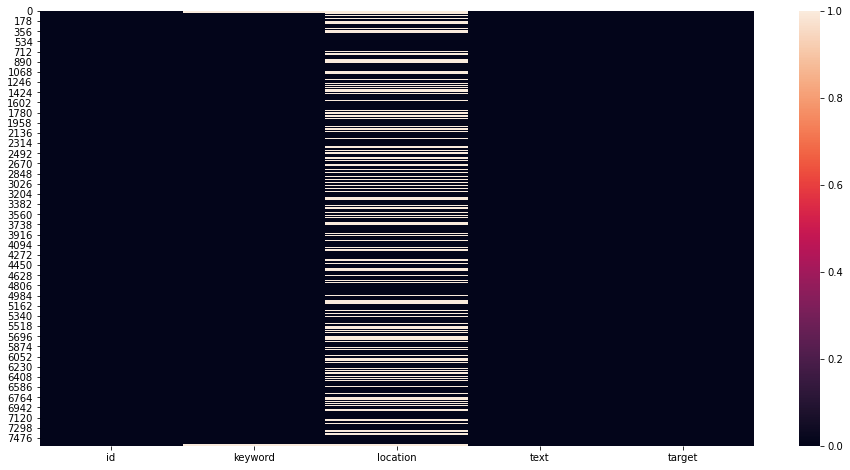

```python
def null_value_analysis(df):
    nulls = df.isnull().sum()
    null_sum = nulls.sum()

    if(null_sum == 0):
        return 'No missing values.'
    else:
        null_df = pd.DataFrame(columns = df.columns)
        null_df.loc['Sum'] = nulls
        null_df.loc['%'] = round((nulls / len(df)) * 100, 1)
        display(null_df)

        # Heatmap
        plt.figure(figsize = (16, 8))
        sns.heatmap(data = df.isnull())
        plt.show()
        null_df

null_value_analysis(df)
```

No missing data for important columns.

```python
del df['keyword']
del df['location']
```

### Append test to train

```python
df = df.append(df_test, ignore_index=True)
```

#### Data preview

```python
for t in df.text[40:60]:
    print(t)
```

```
Check these out: http://t.co/rOI2NSmEJJ http://t.co/3Tj8ZjiN21 http://t.co/YDUiXEfIpE http://t.co/LxTjc87KLS #nsfw
on the outside you're ablaze and alive
but you're dead inside
Had an awesome time visiting the CFC head office the ancop site and ablaze. Thanks to Tita Vida for taking care of us ??
SOOOO PUMPED FOR ABLAZE ???? @southridgelife
I wanted to set Chicago ablaze with my preaching... But not my hotel! http://t.co/o9qknbfOFX
I gained 3 followers in the last week. You? Know your stats and grow with http://t.co/TIyUliF5c6
How the West was burned: Thousands of wildfires ablaze in California alone http://t.co/vl5TBR3wbr
Building the perfect tracklist to life leave the streets ablaze
Check these out: http://t.co/rOI2NSmEJJ http://t.co/3Tj8ZjiN21 http://t.co/YDUiXEfIpE http://t.co/LxTjc87KLS #nsfw
First night with retainers in. It's quite weird. Better get used to it; I have to wear them every single night for the next year at least.
Deputies: Man shot before Brighton home set ablaze http://t.co/gWNRhMSO8k
Man wife get six years jail for setting ablaze niece
http://t.co/eV1ahOUCZA
SANTA CRUZ ÛÓ Head of the St Elizabeth Police Superintendent Lanford Salmon has r ... - http://t.co/vplR5Hka2u http://t.co/SxHW2TNNLf
Police: Arsonist Deliberately Set Black Church In North CarolinaåÊAblaze http://t.co/pcXarbH9An
Noches El-Bestia '@Alexis_Sanchez: happy to see my teammates and training hard ?? goodnight gunners.?????? http://t.co/uc4j4jHvGR'
#Kurds trampling on Turkmen flag later set it ablaze while others vandalized offices of Turkmen Front in #Diyala http://t.co/4IzFdYC3cg
TRUCK ABLAZE : R21. VOORTREKKER AVE. OUTSIDE OR TAMBO INTL. CARGO SECTION. http://t.co/8kscqKfKkF
Set our hearts ablaze and every city was a gift And every skyline was like a kiss upon the lips @Û_ https://t.co/cYoMPZ1A0Z
They sky was ablaze tonight in Los Angeles. I'm expecting IG and FB to be filled with sunset shots if I know my peeps!!
How the West was burned: Thousands of wildfires ablaze in #California alone http://t.co/iCSjGZ9tE1 #climate #energy http://t.co/9FxmN0l0Bd
```

I have to remove mentions, hashtags and website links. But some hashtags are actually part of a sentence. It looks like when hashtag is inside a sentence it's part of that sentence.

I will try to remove hashtags at the end and save rest.

# Data prerocessing

### Lowercase

```python
df['text_basic'] = df['text'].apply(lambda x: x.lower())
```

### Remove websites and mentions

```python
df['text_basic'] = df['text_basic'].apply(lambda x: re.sub(r'@\S+', '', x))
df['text_basic'] = df['text_basic'].apply(lambda x: re.sub(r'http\S+', '', x))
```

### Hashtags

```python
def removeBadHashtags(text):
    lst = text.split()
    for i in range(len(lst) - 1, -1, -1):
        if('#' in lst[i]):
            lst.pop()
        else:
            break
    return ' '.join(lst)
```

```python
# Example - function removed unwanted hashtags
removeBadHashtags('How the West was burned: Thousands of wildfires ablaze in #California alone  #climate #energy ')
```

```
'How the West was burned: Thousands of wildfires ablaze in #California alone'
```

```python
df['text_basic'] = df['text_basic'].apply(lambda x: removeBadHashtags(x))
```

Now I can just remove hashtag symbols.

```python
df['text_basic'] = df['text_basic'].apply(lambda x: x.replace('#', ''))
```

```python
# Final result
df.text_basic[59]
```

```
'how the west was burned: thousands of wildfires ablaze in california alone'
```

### Contradiction mapping

```python
df['text_basic'] = df['text_basic'].apply(lambda x: contractions.fix(x))
```

### Numbers and date

I'll remove date and then all numbers.

```python
reg_ex = [r'(Jan|Feb|Mar|Apr|May|Jun|Jul|Aug|Sep|Oct|Nov|Dec)\s\d{2}\s\d{4}',
    r'(\d{1,2})-(\d{1,2})-(\d{4})$',
    r'(\d{4})-(\d{1,2})-(\d{1,2})$',
    r'(\d{4})-(\d{1,2})$',
    r'(\d{1,2})-(\d{4})$',
    r'(\d{2}\:\d{2})'
]

for rx in reg_ex:
    df['text_basic'] = df['text_basic'].apply(lambda x: re.sub(rx, '', x))
```

```python
df['text_basic'] = df['text_basic'].apply(lambda x: re.sub("\d+", "", x))
```

### Emojis mapping

```python
def mapDictionary(text, dic):
    for c in dic:
        text = text.replace(c, dic[c])
    return text
```

Let's find special emoji symbols.

```python
text = ''
for s in df.text_basic:
    text += s
```

```python
special_emojis = demoji.findall(text)
special_emojis
```

```
{'©': 'copyright'}
```

And some text-based emojis.

```python
text_emojis = {':d':'smile', ':-d':'smile', ':)':'slight smile', ':-)':'slight smile', ';)':'wink smile', ';-)':'wink smile', ';d':'wink smile', ';-d':'wink smile', ':(':' sad ', ':-(':' sad ', ':o':' surprised ', ':-o':' surprised '}
emojis = dict(special_emojis)
emojis.update(text_emojis)
emojis
```

```
{'©': 'copyright',
 ':d': 'smile',
 ':-d': 'smile',
 ':)': 'slight smile',
 ':-)': 'slight smile',
 ';)': 'wink smile',
 ';-)': 'wink smile',
 ';d': 'wink smile',
 ';-d': 'wink smile',
 ':(': ' sad ',
 ':-(': ' sad ',
 ':o': ' surprised ',
 ':-o': ' surprised '}
```

```python
df['text_basic'] = df['text_basic'].apply(lambda x: mapDictionary(x, emojis))
```

### Special chars

Let's take a look at all chars in our text and GloVe.

```python
glove_chars = ''.join([c for c in list(embeddings_index.keys()) if len(c) == 1])
print(len(glove_chars))
print(glove_chars)
```

```
291
,.a"-()i:'$;_1?–2%/3456789!`e&=—0“”sbxcrdmtv#[’+gpqy¥nf‘£k|olw]~huj\{z…½>€}*@à<»«、óαí¼^βφωλσδγθπ„με¾¡ρ¢åψτηƒκé₤è⅓иνζ¿īχáξ⅔вø―οö。‚çсäιüರāа⅛ōæšརསâəυя›ôಕħངоēو‹уñನ˚ದනßгරčאеðತŋಸകಮ⅜ག₂ව·ಪūල¤ὁදêкසವžಗіþរ⅝කúལɛϕནདಲтಯಡœಬý¨ъടමł‟đмಶîь⅞ה镇පයнªམęë乡තлûಟབпសಹ道ɔćରതïěфą￥ר王хἡăıśчэзപʃḳшיòוಳãបʔកбדග⁰дõಜש李жєבតס神ɣ姬人一ю
```

```python
text_chars = ''.join(set(text))
print(len(glove_chars))
print(text_chars)
```

```
291
ñ oi+$&fátç_\?äû)m.n÷s^h!pc£gud:/¨l=>jr¢¤è-v¡xï%`òóêüb«ª],k@}|zeâa*{[à¼w(~yåì©q';ã¬
```

And map some of them.

```python
special_chars_map = {'`':"'", '¨':'"', '´':"'", '"':'"', '‘':"'", '’':"'", '“':'"', '”':'"', '&':' and ', '¢':' cent ', '$':' dollar ', '€':' euro ', '÷':' / ', '£':' pound ', '«':' < ', '&amp;':' and ', '&lt;':' < ', '&gt;':' > '}
```

```python
df['text_basic'] = df['text_basic'].apply(lambda x: mapDictionary(x, special_chars_map))
```

### Tokenization

```python
df['text_token'] = df['text_basic'].apply(lambda x: nltk.tokenize.word_tokenize(x))
```

```python
df.head(10)
```

|  | id | text | target | text_basic | text_token |
| --- | --- | --- | --- | --- | --- |
| 0 | 1 | Our Deeds are the Reason of this #earthquake M... | 1 | our deeds are the reason of this earthquake ma... | [our, deeds, are, the, reason, of, this, earth... |
| 1 | 4 | Forest fire near La Ronge Sask. Canada | 1 | forest fire near la ronge sask. canada | [forest, fire, near, la, ronge, sask, ., canada] |
| 2 | 5 | All residents asked to 'shelter in place' are ... | 1 | all residents asked to 'shelter in place' are ... | [all, residents, asked, to, 'shelter, in, plac... |
| 3 | 6 | 13,000 people receive #wildfires evacuation or... | 1 | , people receive wildfires evacuation orders i... | [,, people, receive, wildfires, evacuation, or... |
| 4 | 7 | Just got sent this photo from Ruby #Alaska as ... | 1 | just got sent this photo from ruby alaska as s... | [just, got, sent, this, photo, from, ruby, ala... |
| 5 | 8 | #RockyFire Update => California Hwy. 20 closed... | 1 | rockyfire update => california hwy. closed in... | [rockyfire, update, =, >, california, hwy, ., ... |
| 6 | 10 | #flood #disaster Heavy rain causes flash flood... | 1 | flood disaster heavy rain causes flash floodin... | [flood, disaster, heavy, rain, causes, flash, ... |
| 7 | 13 | I'm on top of the hill and I can see a fire in... | 1 | i am on top of the hill and i can see a fire i... | [i, am, on, top, of, the, hill, and, i, can, s... |
| 8 | 14 | There's an emergency evacuation happening now ... | 1 | there is an emergency evacuation happening now... | [there, is, an, emergency, evacuation, happeni... |
| 9 | 15 | I'm afraid that the tornado is coming to our a... | 1 | i am afraid that the tornado is coming to our ... | [i, am, afraid, that, the, tornado, is, coming... |

I can now check GloVe coverage and most common problematic words.

```python
not_found_words = emb_coverage(embeddings_index, df['text_token'])
not_found_words.most_common(10)
```

```
Text coverage: 96.31
Vocab coverage: 78.81
```

```
[('..', 187),
 ('\x89û_', 93),
 ('\x89û', 75),
 ('\x89ûò', 68),
 ('you.s', 62),
 ("'the", 44),
 ('\x89ûó', 43),
 ('w/', 39),
 ('//', 37),
 ('re\x89û_', 37)]
```

### Remove 'non-glove' chars

```python
def split(word):
    return [char for char in word]

gc = split(glove_chars)
df['text_token_clean'] = df['text_token'].apply(lambda x: [w for w in x if all(i in gc for i in split(w))])
```

```python
not_found_words = emb_coverage(embeddings_index, df['text_token_clean'])
```

```
Text coverage: 96.95
Vocab coverage: 80.93
```

### Word segmentation

```python
load()
df['text_token_clean'] = df['text_token_clean'].apply(lambda x: [" ".join(segment(w)) if len(w) > 4 else w for w in x])
```

```python
df['text_token_clean'] = df['text_token_clean'].apply(lambda x: " ".join(x))
df['text_token_clean'] = df['text_token_clean'].apply(lambda x: nltk.tokenize.word_tokenize(x.lower()))
```

```python
not_found_words = emb_coverage(embeddings_index, df['text_token_clean'])
```

```
Text coverage: 99.09
Vocab coverage: 94.98
```

99% text coverage after word segmentation.

### Manual work

Let's fix some issues manually.

```python
not_found_words.most_common()[0:20]
```

```
[('..', 187),
 ("'the", 44),
 ('w/', 39),
 ('//', 37),
 ("'we", 36),
 ('i-', 23),
 ('lmao', 21),
 ("'it", 18),
 ('spos', 14),
 ('ok.', 13),
 ('c-', 13),
 ('mediterra', 12),
 ('idk', 11),
 ('trfc', 11),
 ('mht', 11),
 ('hwo', 11),
 ('gbbo', 10),
 ("'if", 9),
 ("'you", 8),
 ('blks', 7)]
```

Some words starts with apostrophe.

```python
df['text_token_clean'] = df['text_token_clean'].apply(lambda x: [w[1:] if w.startswith("'") and len(w) > 1 else w for w in x])
```

```python
fix_dic = {'..':'', '//':'', 'w/':' with ', 'i-':'i', 'lmao':'laughing', 'c-':'', 'hwo':'who', 'idk':'i do not know', 'hahaha':'haha', 'omfg':'oh my god', 'specif':'specific', 'ok.':'ok'}

df['text_token_clean'] = df['text_token_clean'].apply(lambda x: " ".join(x))
df['text_token_clean'] = df['text_token_clean'].apply(lambda x: mapDictionary(x, fix_dic))
df['text_token_clean'] = df['text_token_clean'].apply(lambda x: nltk.tokenize.word_tokenize(x.lower()))
```

```python
not_found_words = emb_coverage(embeddings_index, df['text_token_clean'])
```

```
Text coverage: 99.42
Vocab coverage: 95.46
```

### Final dataset

```python
tokens = set()
for s in df.text_token_clean:
    tmp = set(s)
    tokens.update(tmp)
print('Vocab size: ' + str(len(tokens)))
```

```
Vocab size: 15644
```

```python
df['text_clean'] = df['text_token_clean'].apply(lambda x: " ".join(x))
df['len'] = [len(x) for x in df['text_clean']]
df['len_token'] = [len(x) for x in df['text_token_clean']]
```

```python
df.head(5)
```

|  | id | text | target | text_basic | text_token | text_token_clean | text_clean | len | len_token |
| --- | --- | --- | --- | --- | --- | --- | --- | --- | --- |
| 0 | 1 | Our Deeds are the Reason of this #earthquake M... | 1 | our deeds are the reason of this earthquake ma... | [our, deeds, are, the, reason, of, this, earth... | [our, deeds, are, the, reason, of, this, earth... | our deeds are the reason of this earthquake ma... | 68 | 13 |
| 1 | 4 | Forest fire near La Ronge Sask. Canada | 1 | forest fire near la ronge sask. canada | [forest, fire, near, la, ronge, sask, ., canada] | [forest, fire, near, la, ronge, sask, ., canada] | forest fire near la ronge sask . canada | 39 | 8 |
| 2 | 5 | All residents asked to 'shelter in place' are ... | 1 | all residents asked to 'shelter in place' are ... | [all, residents, asked, to, 'shelter, in, plac... | [all, residents, asked, to, shelter, in, place... | all residents asked to shelter in place ' are ... | 134 | 24 |
| 3 | 6 | 13,000 people receive #wildfires evacuation or... | 1 | , people receive wildfires evacuation orders i... | [,, people, receive, wildfires, evacuation, or... | [,, people, receive, wildfires, evacuation, or... | , people receive wildfires evacuation orders i... | 58 | 8 |
| 4 | 7 | Just got sent this photo from Ruby #Alaska as ... | 1 | just got sent this photo from ruby alaska as s... | [just, got, sent, this, photo, from, ruby, ala... | [just, got, sent, this, photo, from, ruby, ala... | just got sent this photo from ruby alaska as s... | 85 | 16 |

#### Test split

```python
df_test = df[df.target == -1]
df = df[df.target != -1]
```

```python
df_test.head(2)
```

|  | id | text | target | text_basic | text_token | text_token_clean | text_clean | len | len_token |
| --- | --- | --- | --- | --- | --- | --- | --- | --- | --- |
| 7613 | 0 | Just happened a terrible car crash | -1 | just happened a terrible car crash | [just, happened, a, terrible, car, crash] | [just, happened, a, terrible, car, crash] | just happened a terrible car crash | 34 | 6 |
| 7614 | 2 | Heard about #earthquake is different cities, s... | -1 | heard about earthquake is different cities, st... | [heard, about, earthquake, is, different, citi... | [heard, about, earthquake, is, different, citi... | heard about earthquake is different cities , s... | 65 | 11 |

# EDA

#### Data distribution

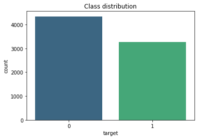

```python
sns.countplot(data = df, x = 'target', palette = pal).set_title('Class distribution')
plt.show()
```

Dataset is little bit unbalanced but nothing terrible.

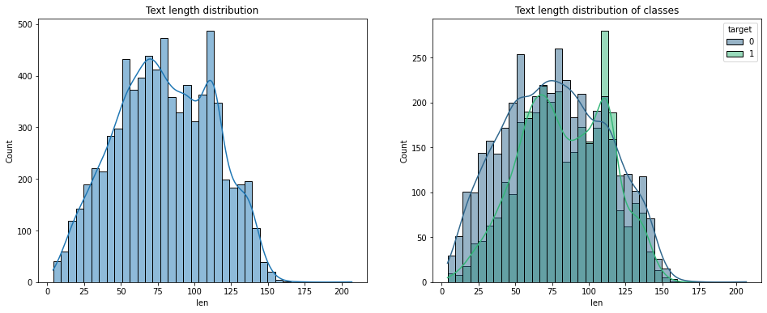

Most texts are shorter than 130 characters.

```python
fig, ax = plt.subplots(1, 2, figsize = (16, 6))
sns.histplot(data = df, x = 'len', kde = True, ax = ax[0], palette = pal).set_title('Text length distribution')
sns.histplot(data = df, x = 'len', kde = True, ax = ax[1], palette = pal, hue = 'target').set_title('Text length distribution of classes')
plt.show()
```

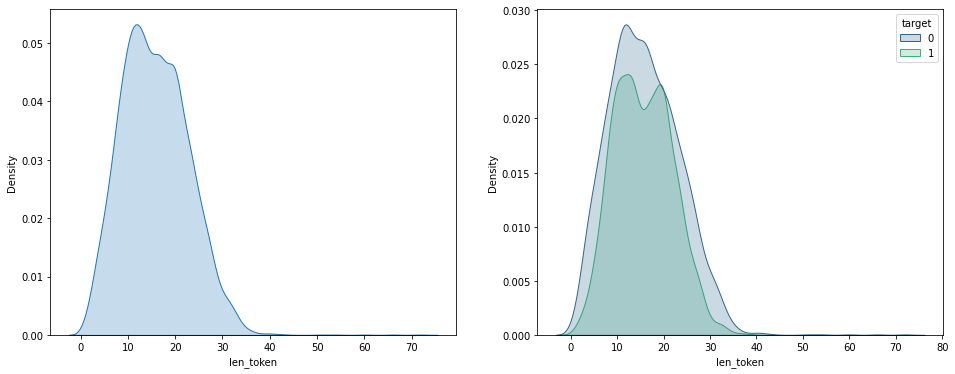

Most texts are shorter than 30 words.

```python
fig, ax = plt.subplots(1, 2, figsize = (16, 6))
sns.kdeplot(data = df, x = 'len_token', fill = True, ax = ax[0], palette = pal)
sns.kdeplot(data = df, x = 'len_token', fill = True, ax = ax[1], palette = pal, hue = 'target')
plt.show()
```

# Model

```python
import tensorflow as tf
import tensorflow.keras as keras
from sklearn.model_selection import train_test_split
from sklearn.metrics import accuracy_score, f1_score, confusion_matrix, classification_report
from tensorflow import string as tf_string
from keras.callbacks import EarlyStopping
from tensorflow.keras.layers.experimental.preprocessing import TextVectorization
from tensorflow.keras.layers import Flatten, LSTM, GRU, MaxPooling1D, Bidirectional, SpatialDropout1D, Conv1D, GlobalMaxPool1D, Dense, Dropout, BatchNormalization, SpatialDropout1D, Activation, concatenate
from tensorflow.compat.v1.keras.layers import CuDNNGRU, CuDNNLSTM
from keras import backend as K
```

### Train-test split.

```python
X_train, X_test, y_train, y_test = train_test_split(df.text_clean, df.target, test_size = 0.1, random_state = 42, stratify = df.target)
# X_train, X_valid, y_train, y_valid = train_test_split(X_train, y_train, test_size = 0.1, random_state = 42, stratify = y_train)
```

### Embedding setup

```python
embedding_dim = 300
vocab_size = 7000
sequence_length = 30

vect_layer = TextVectorization(max_tokens = vocab_size, output_mode = 'int', output_sequence_length = sequence_length)
vect_layer.adapt(df.text_clean.values)
```

```python
voc = vect_layer.get_vocabulary()
word_index = dict(zip(voc, range(len(voc))))
```

```python
num_tokens = len(voc) + 2
hits = 0
misses = 0

embedding_matrix = np.zeros((num_tokens, embedding_dim))
for word, i in word_index.items():
    embedding_vector = embeddings_index.get(word)
    if embedding_vector is not None:
        if(len(embedding_vector) > 0):
            embedding_matrix[i] = embedding_vector
            hits += 1
    else:
        misses += 1
print("Converted %d words (%d misses)" % (hits, misses))
```

```
Converted 6869 words (131 misses)
```

### Model

```python
def showHistory(history):
    plt.figure()
    for key in history.history.keys():
        plt.plot(history.epoch, history.history[key], label=key)
    plt.legend()
    plt.tight_layout()
    plt.show()

def predict(model, x, y):
    y_pred = model.predict(x).ravel()
    y_pred = [1 if x >= 0.5 else 0 for x in y_pred]
    print(f'Accuracy: {accuracy_score(y_true = y, y_pred = y_pred)}')
    print(f'F1 Score: {f1_score(y_true = y, y_pred = y_pred)}')
    cm = confusion_matrix(y_true = y, y_pred = y_pred)
    sns.heatmap(cm, cmap = pal, annot = True, fmt='.0f')
    plt.show()
```

```python
from tensorflow.keras.utils import get_custom_objects
class Mish(Activation):
    def __init__(self, activation, **kwargs):
        super(Mish, self).__init__(activation, **kwargs)
        self.__name__ = "Mish"


def mish(inputs):
    return inputs * tf.math.tanh(tf.math.softplus(inputs))

get_custom_objects().update({"Mish": Mish(mish)})
```

```python
def recall_m(y_true, y_pred):
    true_positives = K.sum(K.round(K.clip(y_true * y_pred, 0, 1)))
    possible_positives = K.sum(K.round(K.clip(y_true, 0, 1)))
    recall = true_positives / (possible_positives + K.epsilon())
    return recall

def precision_m(y_true, y_pred):
    true_positives = K.sum(K.round(K.clip(y_true * y_pred, 0, 1)))
    predicted_positives = K.sum(K.round(K.clip(y_pred, 0, 1)))
    precision = true_positives / (predicted_positives + K.epsilon())
    return precision

def f1_m(y_true, y_pred):
    precision = precision_m(y_true, y_pred)
    recall = recall_m(y_true, y_pred)
    return 2*((precision*recall)/(precision+recall+K.epsilon()))
```

```python
input_layer = keras.layers.Input(shape=(1,), dtype=tf_string)
x_v = vect_layer(input_layer)

# Embedding
emb = keras.layers.Embedding(num_tokens, embedding_dim, embeddings_initializer = keras.initializers.Constant(embedding_matrix), trainable = False)(x_v)
x = SpatialDropout1D(0.2)(emb)

# RNN
x = Bidirectional(CuDNNGRU(64, return_sequences = True))(x)
x = Bidirectional(CuDNNGRU(64, return_sequences = True))(x)
x = GlobalMaxPool1D()(x)

# Dense
x = Dense(32, activation = 'Mish')(x)
x = Dropout(0.2)(x)

output_layer = Dense(1, 'sigmoid')(x)

model = keras.Model(input_layer, output_layer)
```

```
Epoch 73: early stopping
```

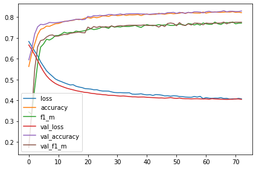

```
Accuracy: 0.8293963254593176
F1 Score: 0.7936507936507937
```

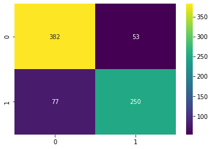

```python
opt = keras.optimizers.Adam(learning_rate = 0.00001)
model.compile(optimizer = opt, loss = keras.losses.BinaryCrossentropy(), metrics = ['accuracy', f1_m])

es = EarlyStopping(monitor = 'val_loss', patience = 5, verbose = 1)

batch_size = 32
epochs = 200

history = model.fit(X_train.values, y_train.values, validation_data = (X_test, y_test), callbacks = [es], epochs = epochs, batch_size = batch_size)

showHistory(history)
predict(model, X_test, y_test)
```

#### Kaggle competition submission

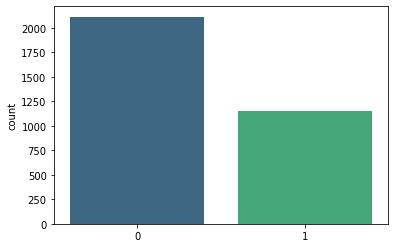

```python
# 0.80907 public f1 score
y_pred = model.predict(df_test.text_clean).ravel()
y_pred = [1 if x >= 0.5 else 0 for x in y_pred]

sns.countplot(x = y_pred, palette = pal)
plt.show()

sub_df = pd.DataFrame({'id' : df_test['id'].values.tolist(), 'target' : y_pred})
sub_df.to_csv('submission.csv', index = False)
```

### Model selection

```python
res = {'models': ['GRU(128) + D(32)', 'LSTM(128) + D(32)', 'BiLSTM(128) + D(32)', 'BiGRU(128) + D(32)', '2xBiGRU(64) + D(32)', '2xBiGRU(128 & 64) + D(32)', 'BiLSTM(80) + BiGRU(64) + D(32)', 'Conv1D(64, 3) + 2xBiGRU(128 & 64) + D(32)', 'Conv1D(64, 4) + 2xBiGRU(128 & 64) + D(32)', '3xBiGRU(64) + D(32)'], 'accuracy': [0.822, 0.830, 0.832, 0.831, 0.833, 0.83, 0.821, 0.833, 0.821, 0.827], 'f1': [0.792, 0.789, 0.786, 0.796, 0.802, 0.790, 0.791, 0.793, 0.77, 0.794]}
models_results = pd.DataFrame(res).set_index('models')
models_results.style.background_gradient(cmap = pal)
```

| models | accuracy | f1 |
| --- | --- | --- |
| GRU(128) + D(32) | 0.822000 | 0.792000 |
| LSTM(128) + D(32) | 0.830000 | 0.789000 |
| BiLSTM(128) + D(32) | 0.832000 | 0.786000 |
| BiGRU(128) + D(32) | 0.831000 | 0.796000 |
| 2xBiGRU(64) + D(32) | 0.833000 | 0.802000 |
| 2xBiGRU(128 & 64) + D(32) | 0.830000 | 0.790000 |
| BiLSTM(80) + BiGRU(64) + D(32) | 0.821000 | 0.791000 |
| Conv1D(64, 3) + 2xBiGRU(128 & 64) + D(32) | 0.833000 | 0.793000 |
| Conv1D(64, 4) + 2xBiGRU(128 & 64) + D(32) | 0.821000 | 0.770000 |
| 3xBiGRU(64) + D(32) | 0.827000 | 0.794000 |

Best performing model is 2xBiGRU(64) + D(32).

### Hyperparameter tuning

basic: 2xBiGRU(64) + D(32), batch_size = 32, sequence_length = 25, trainable = False, vocab_size = 7000, learning_rate = 0.00005

```python
res = {'configurations': ['basic', 'D(64) + D(32)', 'batch_size = 64', 'batch_size = 16', 'trainable = True', 'vocab_size = 8000', 'vocab_size = 6000', 'sequence_length = 30', 'learning_rate = 0.00001'], 'accuracy': [0.833, 0.815, 0.829, 0.832, 0.825, 0.825, 0.820, 0.838, 0.831], 'f1': [0.802, 0.790, 0.797, 0.798, 0.788, 0.790, 0.789, 0.806, 0.800]}
hyp_results = pd.DataFrame(res).set_index('configurations')
hyp_results.style.background_gradient(cmap = pal)
```

| configurations | accuracy | f1 |
| --- | --- | --- |
| basic | 0.833000 | 0.802000 |
| D(64) + D(32) | 0.815000 | 0.790000 |
| batch_size = 64 | 0.829000 | 0.797000 |
| batch_size = 16 | 0.832000 | 0.798000 |
| trainable = True | 0.825000 | 0.788000 |
| vocab_size = 8000 | 0.825000 | 0.790000 |
| vocab_size = 6000 | 0.820000 | 0.789000 |
| sequence_length = 30 | 0.838000 | 0.806000 |
| learning_rate = 0.00001 | 0.831000 | 0.800000 |

# Conclusion

For preprocessing, I tried to maximize coverage of vocabulary and text and I ended up with 99.42% / 95.46% coverage.

Best performing model at the end was 2-layer bidirectional GRU on wiki-glove with dimension 300.

The final model achieved F1 score of 80.6%, which is a 5.5% improvement over the model with my own embedding layer (previously tested).